# Model Building with `caret` (Nominal Outcomes)

### 4. Measuring Model Performance

Many of the performance measures used for binary categorical outcomes can also be used for nominal categorical outcomes, though some additional nuances are required. In this section we will revisit each of these measures and see how it extends to nominal categorical outcomes.

#### Accuracy

Recall that *accuracy* is proportion of correct classifications the model makes: $\text{Accuracy} = \Sigma_{i=1}^{n}(y_i = \hat{y}_i)/n$; unsurprisingly this measure is easily adapted to nominal outcomes, though we still require decision rule to map the predicted probabilities from the model to a predicted category.

In most circumstances, predicted probabilities are mapped to the “most likely” category. Suppose our outcome variable has $k$ categories, we can express this decision rule mathematically:

$$\hat{y}_i = \text{cat}_1 \text{ if } \hat{\pi}_{i,k=1} \geq \hat{\pi}_{i,k \ne 1} \\
\hat{y}_i = \text{cat}_2 \text{ if } \hat{\pi}_{i,k=2} \geq \hat{\pi}_{i,k \ne 2} \\
\ldots$$

The code below demonstrates how this can be done using the matrix of predicted probabilities stored as `fitted.values` in the fitted model from `multinom`.

```r
most_likely <- apply(mfit$fitted.values, 1, which.max) ## Applies the which.max function to each row of the matrix of predicted probabilities

pred_cats <- levels(iris$Species)[most_likely]  ## Map the maximums (either 1, 2, or 3) to category labels

sum(pred_cats == iris$Species)/nrow(iris) ## Calculate the fraction of correct predictions (ie: accuracy)
```

```
## [1] 0.7466667
```

We can see that our multinomial logistic regression model that uses `Sepal.Length` as a predictor achieves approximately 75% accuracy.

#### Kappa

Cohen’s kappa is considerably more complex to calculate. Since its basic interpretation remains the same, we won’t dive into these details, though if you are curious [this document](https://psych.unl.edu/psycrs/handcomp/hckappa.PDF) explains the idea pretty clearly.

You should view kappa as a measure of how this model’s classifications compare to what might be expected by random chance. We will rely on the functions in the `caret` package to calculate kappa for us when dealing with nominal categorical outcomes.

#### ROC (sensitivity and specificity)

ROC analysis was designed for situations involving binary variables, nevertheless there are several proposed extensions to nominal outocmes. The `multiclass.roc` provides one way of calculating the AUC (a summary of sensitivity and specificity) of a model:

```r
multiclass.roc(iris$Species, mfit$fitted.values)
```

```
##
## Call:
## multiclass.roc.default(response = iris$Species, predictor = mfit$fitted.values)
##
## Data: multivariate predictor mfit$fitted.values with 3 levels of iris$Species: setosa, versicolor, virginica.
## Multi-class area under the curve: 0.8737
```

We will avoid discussing sensitivity and specificity as they only make sense for binary comparisons. If these measures of interest in your application, you should consider reframing your data to contain a binary outcome (either by filtering or consolidating categories).

### 4. Cross-validation via `caret`

Cross-validating models with nominal categorical outcomes using `caret` is no different than cross-validating a model with a binary outcome (with the expectation that the “twoClassSummary” option is no longer valid). Recall that there are two key steps in this process:

```r
fit.control <- trainControl(method = "repeatedcv", number = 5, repeats = 10)

set.seed(123)
fit <- train(Species ~ Sepal.Length, data = iris, method = "multinom", trControl = fit.control, trace = FALSE)

fit
```

```
## Penalized Multinomial Regression
##
## 150 samples
##   1 predictor
##   3 classes: 'setosa', 'versicolor', 'virginica'
##
## No pre-processing
## Resampling: Cross-Validated (5 fold, repeated 10 times)
## Summary of sample sizes: 120, 120, 120, 120, 120, 120, ...
## Resampling results across tuning parameters:
##
##   decay  Accuracy   Kappa
##   0e+00  0.7353333  0.603
##   1e-04  0.7366667  0.605
##   1e-01  0.7233333  0.585
##
## Accuracy was used to select the optimal model using the largest value.
## The final value used for the model was decay = 1e-04.
```

```r
confusionMatrix(fit)
```

```
## Cross-Validated (5 fold, repeated 10 times) Confusion Matrix
##
## (entries are percentual average cell counts across resamples)
##
##             Reference
## Prediction   setosa versicolor virginica
##   setosa       29.1        3.9       0.7
##   versicolor    4.2       20.0       8.1
##   virginica     0.0        9.4      24.5
##
##  Accuracy (average) : 0.7367
```

In this example you should notice:

- The argument `trace = FALSE` is used to suppress superfluous output (try running `train` without it), but this argument doesn’t exist for some methods.
- The `method = "multinom"` fits penalized (regularized) multinomial regression models, this ties into the relationship between multinomial regression and neural networks and isn’t something we will concern ourselves with. The value `decay = 0` corresponds with the multinomial logistic regression model that we’ve been working with throughout this lab.
- *Out-of-sample accuracy* is slightly worse than *in-sample accuracy* (recall we had calculated 75% accuracy for this model)
- The `confusionMatrix` function displays a more detailed summary of the model’s classification accuracy, this can be used to inform situations where the model works better/worse.

**Question #2**:

Use the `resamples` function to compare the accuracy of the model specified above (ie: `Species ~ Sepal.Length`) with a model that uses all four available predictors. Which model you do believe does a better job predicting `Species`?

### 5. Classification and Regression Trees

Multinomial logistic regression is arguably the most interpretable model for nominal categorical outcomes; however, as you might have felt during this lab, it is still a pretty difficult model to make sense of. For that reason, we’ll now introduce a very different type of model: classification and regression trees (sometimes abbreviated CART for short).

Trees are “trained” by recursively partitioning the $p$-dimensional space (defined by the explanatory variables) until an acceptable level of separation or “purity” is achieved within each partition.

This idea is best illustrated by looking at an actual tree. The code below uses the `rpart` function in the `rpart` package to fit a classification tree on the iris data using the variables `Sepal.Length` and `Sepal.Width` as predictors.

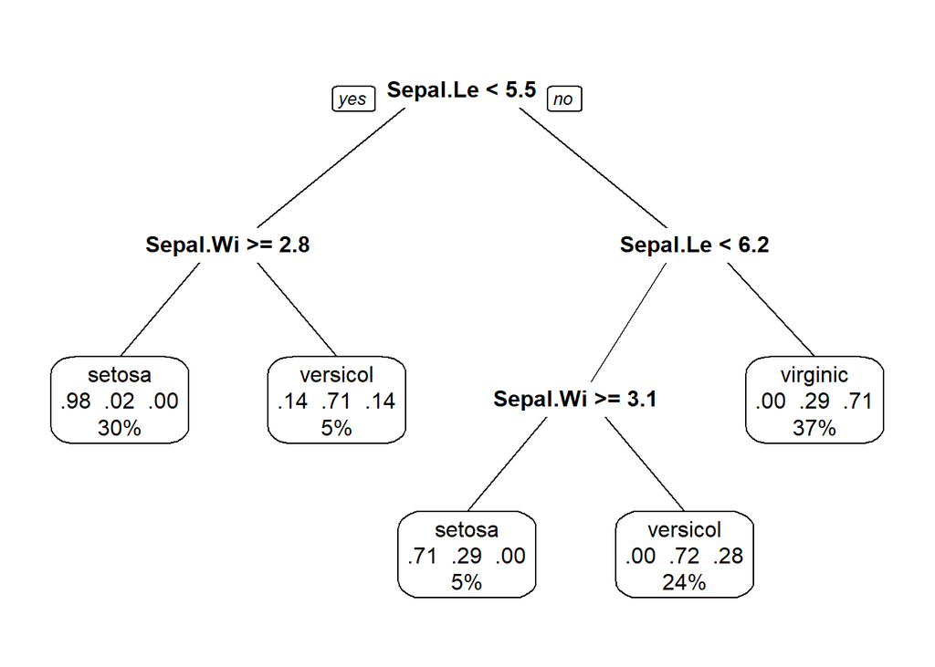

```r
mytree <- rpart(Species ~ Sepal.Length + Sepal.Width, data = iris)
prp(mytree, extra=104) ## "extra = 104" adds some info to the tree, use ?prp to see the details
```

To understand this tree we’ll begin by deciphering the information in the first “node” (shown at the top of the tree).

The core concept behind trees is that nodes are split to achieve better “purity”. In this tree, the first node was split using the decision rule “Sepal.Length < 5.5”, flowers that satisfy this condition are sent to “branch” on the left, and flowers that don’t satisfy this condition are sent to the branch on the right.

We can see how this split partitions the data into visually:

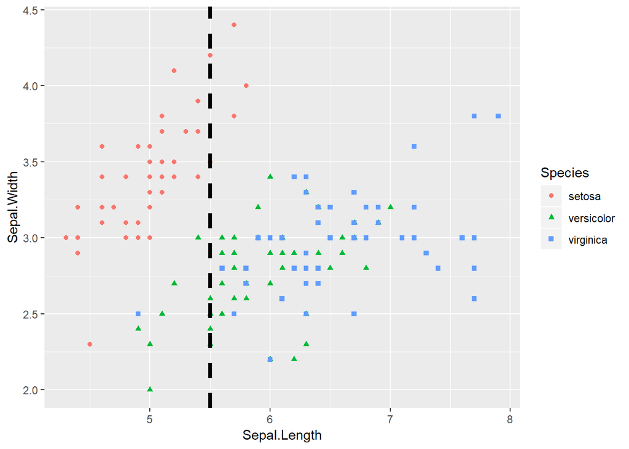

```r
ggplot(iris, aes(x = Sepal.Length, y = Sepal.Width, color = Species, pch = Species)) + geom_point() + geom_vline(xintercept = 5.5, lty = 2, lwd = 1.5)
```

Next the nodes in the left and right branch are each split again. The node in the left branch is split using decision rule “Sepal.Width $\geq$ 2.8”, while the node in the right branch is split using to the decision rule “Sepal.Length < 6.2”; these splits are shown visually in the plot below:

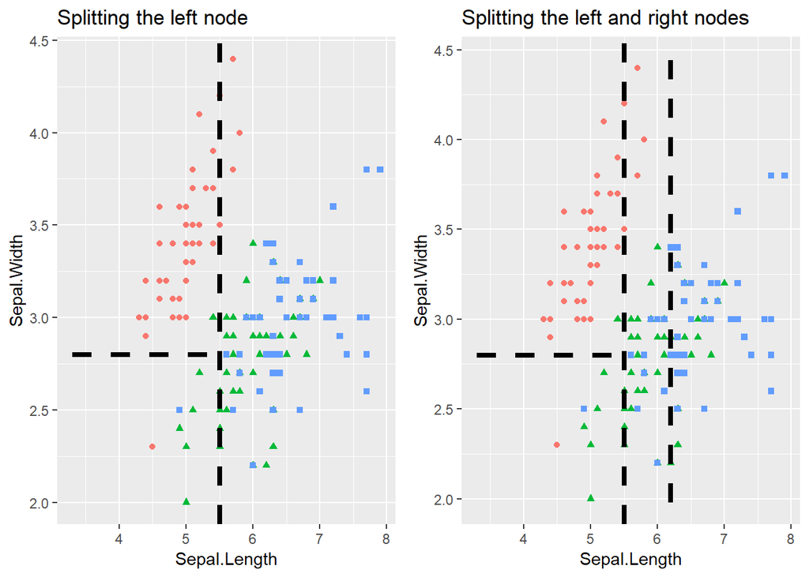

```r
p1 <- ggplot(iris, aes(x = Sepal.Length, y = Sepal.Width, color = Species, pch = Species)) + geom_point() + geom_vline(xintercept = 5.5, lty = 2, lwd = 1.5) + geom_segment(aes(x = min(iris$Sepal.Length-1), y = 2.8, xend = 5.5, yend = 2.8), lwd = 1.5, lty  =2, color = "black") + labs(title = "Splitting the left node") + theme(legend.position = "none")

p2 <- ggplot(iris, aes(x = Sepal.Length, y = Sepal.Width, color = Species, pch = Species)) + geom_point() + geom_vline(xintercept = 5.5, lty = 2, lwd = 1.5) + geom_segment(aes(x = min(iris$Sepal.Length-1), y = 2.8, xend = 5.5, yend = 2.8), lwd = 1.5, lty  =2, color = "black") + geom_segment(aes(x = 6.2, y = 1.98, xend = 6.2, yend = 4.45), lwd = 1.5, lty  =2, color = "black")+ labs(title = "Splitting the left and right nodes") + theme(legend.position = "none")

gridExtra::grid.arrange(p1, p2, nrow = 1)
```

As you can see in the above plot, the classification tree algorithm recursively partitions the two-dimensional space (defined by `Sepal.Width` and `Sepal.Length`) in order to optimally separate the three categories of iris. At this point we’ve described the first 4 nodes, 2 on the left branch and 2 on the right branch. The final tree includes one additional split (the third of these nodes is split using “Sepal.Width $\geq$ 3.1”), a visual representation of this tree is shown below:

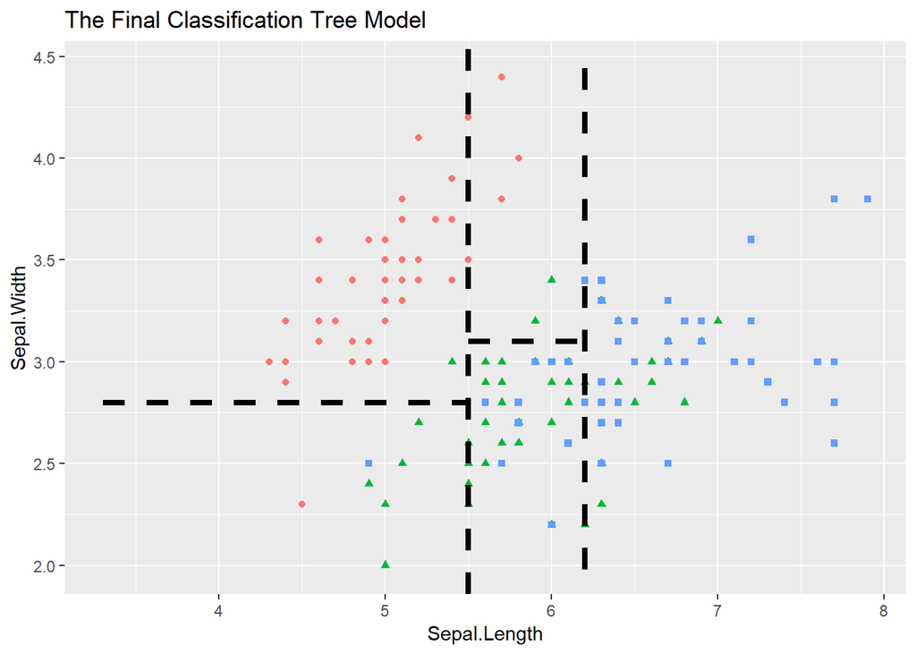

```r
ggplot(iris, aes(x = Sepal.Length, y = Sepal.Width, color = Species, pch = Species)) + geom_point() + geom_vline(xintercept = 5.5, lty = 2, lwd = 1.5) + geom_segment(aes(x = min(iris$Sepal.Length-1), y = 2.8, xend = 5.5, yend = 2.8), lwd = 1.5, lty  =2, color = "black") + geom_segment(aes(x = 6.2, y = 1.98, xend = 6.2, yend = 4.45), lwd = 1.5, lty  =2, color = "black") + geom_segment(aes(x = 5.5, y = 3.1, xend = 6.2, yend = 3.1), lwd = 1.5, lty  =2, color = "black") +
  labs(title = "The Final Classification Tree Model") + theme(legend.position = "none")
```

**Question #3**:

Fit a classification and regression tree to the iris dataset that uses all four predictor variables. Use the `prp` function the `rpart.plot` package to plot the tree (include the argument `extra = 104`). After plotting your tree, briefly describe the 2 splits it makes, then state what percentage of the dataset would be mis-classified if each data-point were predicted to be the dominant species in the node it is contained in.

**Remark**: You should recognize that regression trees can also be applied to numeric outcome variables.

#### Pruning

The CART algorithm will consider splitting any (or all) of these nodes until a stopping criterion is reached. We will not go in-depth into possible stopping rules, but they generally depend upon one or more the following factors:

- Purity of a node
- Data-points in a node
- Depth of the tree (how many splits occured)

Had we desired a tree of a particular depth, we could “prune” our tree by tuning the complexity parameter `cp`, an internal parameter used to determine when the recursive partitioning algorithm should stop:

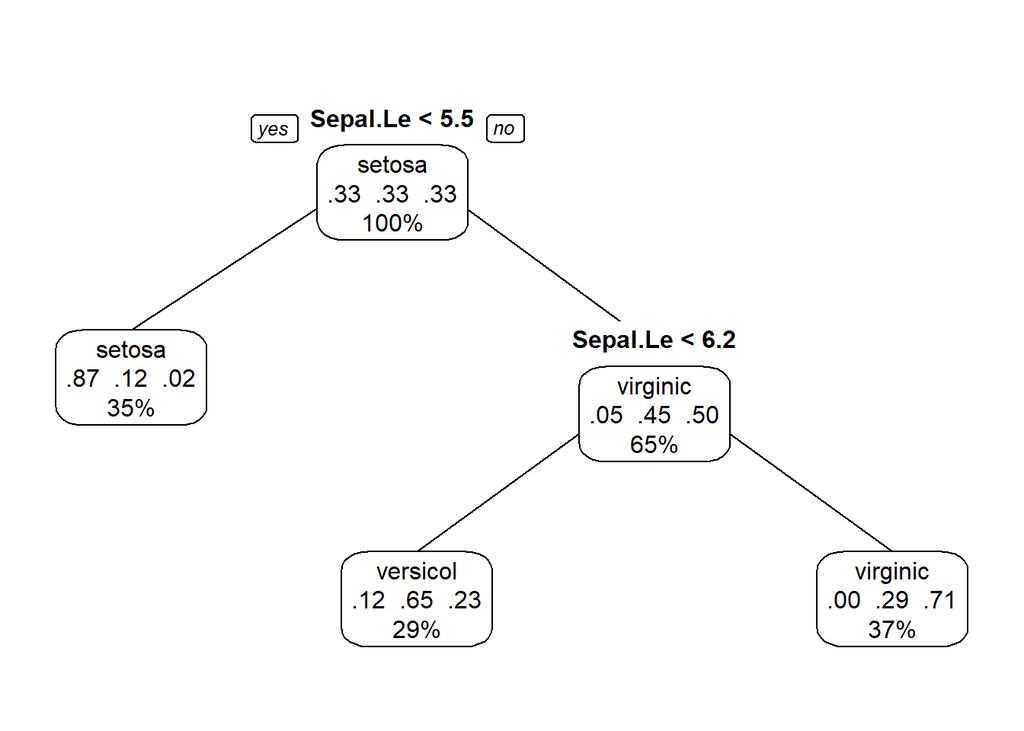

```r
mytree <- rpart(Species ~ Sepal.Length + Sepal.Width, data = iris)
newtree <- prune(mytree, cp = .1)
prp(newtree, type = 1, extra=104)
```

#### Cross-Validation

Proper stopping rules and pruning is essential when using trees to make generalizable predictions due to their tendency towards over-fitting. Fortunately, cross-validation provides us a tool for appropriate pruning a tree in order to maximize it’s out-of-sample predictive ability.

The code below uses the `caret` package to compare the predictive ability of trees and multinomial logistic regression:

```r
fit.control <- trainControl(method = "repeatedcv", number = 5, repeats = 10)

set.seed(123)
fit1 <- train(Species ~ ., data = iris, method = "multinom", trControl = fit.control, trace = FALSE)

set.seed(123)
fit2 <- train(Species ~ ., data = iris, method = "rpart", trControl = fit.control)


rs <- resamples(list(mlr = fit1, tree = fit2))
summary(rs)
```

```
##
## Call:
## summary.resamples(object = rs)
##
## Models: mlr, tree
## Number of resamples: 50
##
## Accuracy
##           Min.   1st Qu.    Median      Mean   3rd Qu. Max. NA's
## mlr  0.9333333 0.9666667 0.9666667 0.9706667 1.0000000    1    0
## tree 0.8333333 0.9000000 0.9333333 0.9320000 0.9666667    1    0
##
## Kappa
##      Min. 1st Qu. Median  Mean 3rd Qu. Max. NA's
## mlr  0.90    0.95   0.95 0.956    1.00    1    0
## tree 0.75    0.85   0.90 0.898    0.95    1    0
```

Notice how multinomial logistic regression outperforms classification trees on this dataset. The reason for this is due to the tendency of trees to overfit the data. In the next section we’ll briefly introduce a “black box” model known as random forests that addresses this issue

### 6. Random Forests

The major issue with trees is they tend to have *high variance* (high propensity towards over-fitting). The theory behind random forests rely upon the fundamental premise that averaging a set of independent elements results in lower variability than any of the individual elements itself had.

This should seem vaguely familiar, thinking back to your intro stat course you might remember that the sample mean $\bar{x}$ has less variability ($\sigma/\sqrt{n}$) than the individual data-points themselves have ($\sigma$). To make use of this fact, we need to introduce a procedure called **bagging** (which is short for bootstrap aggregation).

The goal of bagging is to produce $B$ separate training datasets that are independent of each other. The model of interest (in this case classification and regression trees) is trained on each of these datasets, resulting in $B$ estimates of $f(\mathbf{X})$. These estimates are then averaged to produce a single, low-variance estimate. Bagging is a general approach, but its most well-known application is in random forests.

The random forest algorithm:

1. Construct $B$ bootstrap samples from the original dataset
2. Fit a classification and regression tree to each sample, but at each potential split only a sample set of $m$ predictors are eligible to split on
3. For a given data-point $\mathbf{x}_i$, each of the $B$ trees in the forest contributes a prediction or “vote”, with the majority (or average) of these votes being the random forest’s prediction, $\hat{y}_i$

**Remark**: Bootstrapping isn’t enough to decorrelate the $B$ classification and regression trees. By mandating each split only considers a random set of $m$ predictors the strongest explanatory variables are prevented from dominating every tree (at the expense of other variables that might still provide moderate predictive value), thereby resulting in trees that roughly independent.

The argument `method = "rf"` is used to train a random forest model using `caret`:

```r
fit.control <- trainControl(method = "repeatedcv", number = 5, repeats = 10)

set.seed(123)
fit1 <- train(Species ~ ., data = iris, method = "multinom", trControl = fit.control, trace = FALSE)

set.seed(123)
fit2 <- train(Species ~ ., data = iris, method = "rpart", trControl = fit.control)

set.seed(123)
fit3 <- train(Species ~ ., data = iris, method = "rf", trControl = fit.control)

rs <- resamples(list(mlr = fit1, tree = fit2, rf = fit3))
summary(rs)
```

```
##
## Call:
## summary.resamples(object = rs)
##
## Models: mlr, tree, rf
## Number of resamples: 50
##
## Accuracy
##           Min.   1st Qu.    Median      Mean   3rd Qu. Max. NA's
## mlr  0.9333333 0.9666667 0.9666667 0.9706667 1.0000000    1    0
## tree 0.8333333 0.9000000 0.9333333 0.9320000 0.9666667    1    0
## rf   0.8333333 0.9333333 0.9666667 0.9493333 0.9666667    1    0
##
## Kappa
##      Min. 1st Qu. Median  Mean 3rd Qu. Max. NA's
## mlr  0.90    0.95   0.95 0.956    1.00    1    0
## tree 0.75    0.85   0.90 0.898    0.95    1    0
## rf   0.75    0.90   0.95 0.924    0.95    1    0
```

Here we see that the random forest method performs better than a single classification and regression tree (and about the same as the multinomial logistic regression model).

**Question 4**:

Print the final random forest model (which is stored in `fit3$finalModel` in the code chunk above). What are the values $B$ and $m$ used by this model?

### 7. Practice

When studying PCA, we were exposed to wine dataset stored the UC-Irvine machine learning data repository. This dataset contains wine samples from three different growers in the same region of Italy. The goal of this analysis will be to correctly identify which wines came from which growers.

The code below reads these data:

```r
wine <- read.table("http://archive.ics.uci.edu/ml/machine-learning-databases/wine/wine.data", sep=",")
colnames(wine) <- c("GrowerID" ,"Alcohol", "MalicAcid", "Ash", "Alkalinity", "Mg", "TotalPhenols", "Flavanoids", "NonFlavanoidPhenols", "Proanthocyanins", "ColorIntensity", "Hue", "OD280-OD315Ratio", "Proline")
wine$GrowerID <- factor(wine$GrowerID)
colnames(wine) <- make.names(colnames(wine))
```

**Question 5**:

Fit a multinomial logistic regression model using `Alcohol` to predict `GrowerID`. Interpret the effect of `Alcohol` for the following comparisons of growers: Grower 1 relative to Grower 2, Grower 2 relative to Grower 3, Grower 1 relative to Grower 3. (Hint: make sure you are not treating `GrowerID` as a numeric variableS)

**Question 6**:

Use the `rpart` function to fit a classification tree to the `wine` data to predict Grower ID using all other variables as predictors. Then use the `prp` function to visualize your tree, and answer the following:

**A**: What is the first split made by this tree? How many wines were separated into the left and right branches? **B**: Explain the information in the bottom right node of this tree (ie: what do the three rows tell you?)

**Question 7**:

Use the `caret` package to compare the out-of-sample performance of classification tree and multinomial models. Use all available predictors for both models.

**Question 8**:

Use the `caret` package to determine the out-of-sample performance of a random forest model. How does this performance compare to the models you trained in Question 7? Why do you think the performance of this model is much better than the models from Question 7?

[interactive chart not shown]